# Markdown

Ji

2022-10-05

## Reproducible Research Project 1

### Goal of project:

1. Analyze people’s daily steps.
2. Practice data cleaning, coding and documentation skills.

### Source of data:

Data was obtained by a personal activity monitoring device. The device collects data at 5 minute intervals through out the day. The data consists of two months of data from an anonymous individual collected during the months of October and November, 2012 and include the number of steps taken in 5 minute intervals each day.

Link to download the data: https://d396qusza40orc.cloudfront.net/repdata%2Fdata%2Factivity.zip

### Description of data:

The variables included in this dataset are:  
**steps**: Number of steps taking in a 5-minute interval (missing values are coded as NA.  
**date**: The date on which the measurement was taken in YYYY-MM-DD format  
**interval**: Identifier for the 5-minute interval in which measurement was taken.

### Loading data

```r
# create path to save data
if(!file.exists("./raw_data")){
  dir.create("./raw_data")
}

# download, unzip and read data
url<-"https://d396qusza40orc.cloudfront.net/repdata%2Fdata%2Factivity.zip"
download.file(url,"./raw_data/download.zip")
unzip(zipfile="./raw_data/download.zip",exdir="./raw_data")
data<-read.csv("./raw_data/activity.csv")
head(data)
```

```
##   steps       date interval
## 1    NA 2012-10-01        0
## 2    NA 2012-10-01        5
## 3    NA 2012-10-01       10
## 4    NA 2012-10-01       15
## 5    NA 2012-10-01       20
## 6    NA 2012-10-01       25
```

```r
str(data)
```

```
## 'data.frame':    17568 obs. of  3 variables:
##  $ steps   : int  NA NA NA NA NA NA NA NA NA NA ...
##  $ date    : chr  "2012-10-01" "2012-10-01" "2012-10-01" "2012-10-01" ...
##  $ interval: int  0 5 10 15 20 25 30 35 40 45 ...
```

### Data cleaning

```r
# convert date to Date format
data$date<-as.Date(data$date,"%Y-%m-%d")
class(data$date)
```

```
## [1] "Date"
```

```r
# check how many NA are in each column
steps_na<-sum(is.na(data$steps)=="TRUE") # 2304 na
date_na<-sum(is.na(data$date)=="TRUE") # 0
interval_na<-sum(is.na(data$interval)=="TRUE") # 0
print(paste("missing steps:",steps_na))
```

```
## [1] "missing steps: 2304"
```

```r
print(paste("missing date:",date_na))
```

```
## [1] "missing date: 0"
```

```r
print(paste("missing interval:",interval_na))
```

```
## [1] "missing interval: 0"
```

How to deal with missing steps? Leave the NA, don’t fill it with 0. 0 will affect calculation of mean and median.

### Histogram of the total number of steps taken each day

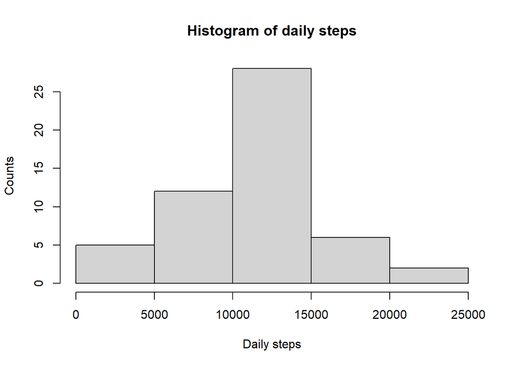

```r
# total numbers of steps for each day
steps_day<-aggregate(data$steps, list(data$date), sum)
colnames(steps_day)<-c("date","steps")

# get histogram
hist(steps_day$steps,main="Histogram of daily steps",xlab="Daily steps",ylab="Counts")
```

### Mean and median number of steps taken each day

```r
# get mean and median
mean<-mean(steps_day$steps,na.rm=TRUE)
median<-median(steps_day$steps,na.rm=TRUE)
print(paste("The mean steps taken per day is:",mean))
```

```
## [1] "The mean steps taken per day is: 10766.1886792453"
```

```r
print(paste("The median steps taken per day is:",median))
```

```
## [1] "The median steps taken per day is: 10765"
```

### Time series plot of the average number of steps taken

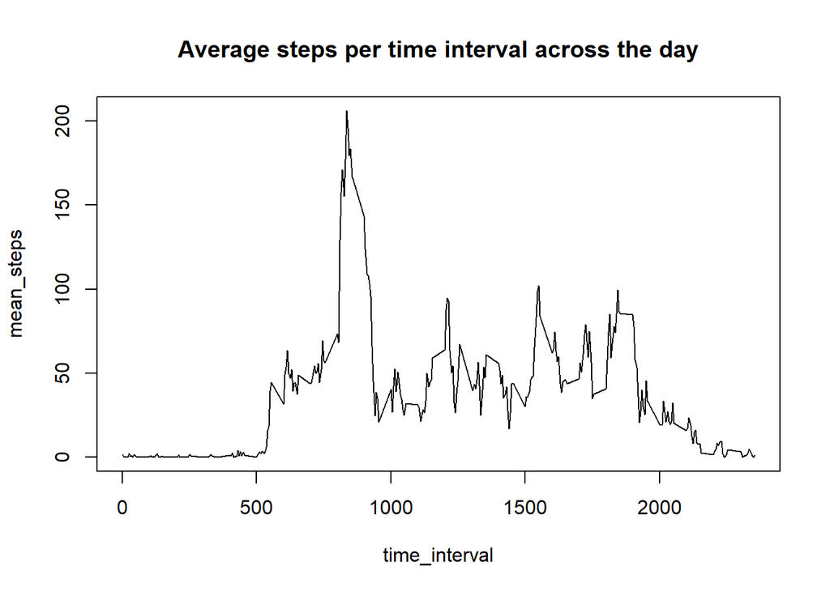

```r
# time series plot of average
steps_interval<-aggregate(data$steps, list(data$interval), mean,na.rm=TRUE)
colnames(steps_interval)<-c("time_interval","mean_steps")
with(steps_interval,plot(time_interval, mean_steps,type="l",main="Average steps per time interval across the day"))
```

### The 5-minute interval that, on average, contains the maximum number of steps

```r
time_interval_max<-steps_interval[which.max(steps_interval$mean_steps),"time_interval"]
print(paste("The",time_interval_max,"interval has the max average steps across the day."))
```

```
## [1] "The 835 interval has the max average steps across the day."
```

### Code to describe and show a strategy for imputing missing data

```r
# impute missing values
row_NA<-sum(complete.cases(data)=="FALSE")
print(paste("There are",row_NA,"rows with NA."))
```

```
## [1] "There are 2304 rows with NA."
```

```r
# fill missing steps with mean of that 5 min interval
# create a new data frame
data_v1<-data
na_index<-which(is.na(data_v1$steps))

for(i in na_index){
  time_interval<-data_v1[i,"interval"]
  time_index<-which(steps_interval$time_interval==time_interval)
  data_v1[i,"steps"]<-steps_interval[time_index,"mean_steps"]
}

steps_day_v1<-aggregate(data_v1$steps, list(data_v1$date), sum)
colnames(steps_day_v1)<-c("date","steps")
```

### Histogram of the total number of steps taken each day after missing values are imputed

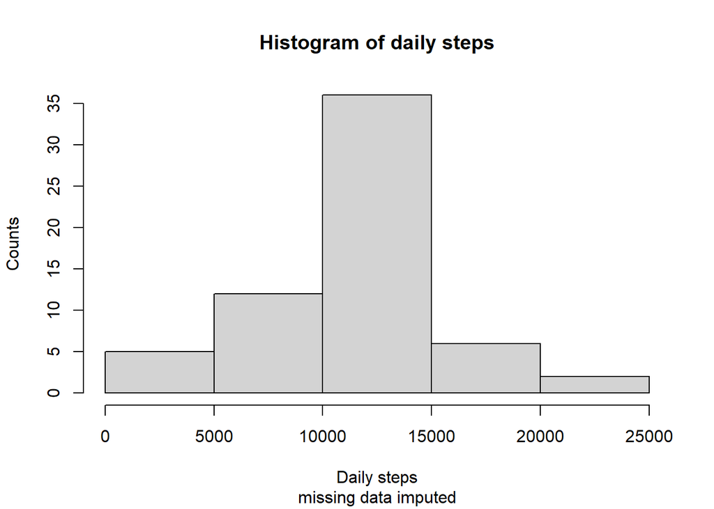

```r
# make a histogram
hist(steps_day_v1$steps,main="Histogram of daily steps",sub="missing data imputed",xlab="Daily steps",ylab="Counts")
```

### Mean and median and comparison

```r
# get mean and median
mean_v1<-mean(steps_day_v1$steps,na.rm=TRUE)
median_v1<-median(steps_day_v1$steps,na.rm=TRUE)
print(paste("The mean steps taken per day is:",mean_v1))
```

```
## [1] "The mean steps taken per day is: 10766.1886792453"
```

```r
print(paste("The median steps taken per day is:",median_v1))
```

```
## [1] "The median steps taken per day is: 10766.1886792453"
```

```r
# compare mean and median of original and imputed missing data
raw<-c(mean, median)
missing_value_imputed<-c(mean_v1,median_v1)
compare<-data.frame(raw,missing_value_imputed)
rownames(compare)<-c("mean", "median")
compare
```

```
##             raw missing_value_imputed
## mean   10766.19              10766.19
## median 10765.00              10766.19
```

Got a larger median number after imputing missing values.

### Panel plot comparing the average number of steps taken per 5-minute interval across weekdays and weekends

```r
# differences between weekdays and weekends
data_v1$days<-weekdays(data_v1$date)
install.packages("data.table",repos = "http://cran.us.r-project.org")
library(data.table)
DT<-data.table(data_v1)
DT<-DT[,Labels:="weekday"]
DT<-DT[days %in% c("Saturday","Sunday"),Labels:="weekend"]

steps_time_Wdays<-aggregate(DT$steps,list(DT$Labels,DT$interval),mean)
colnames(steps_time_Wdays)<-c("wday","time_interval","steps")

install.packages("lattice",repos = "http://cran.us.r-project.org")
```

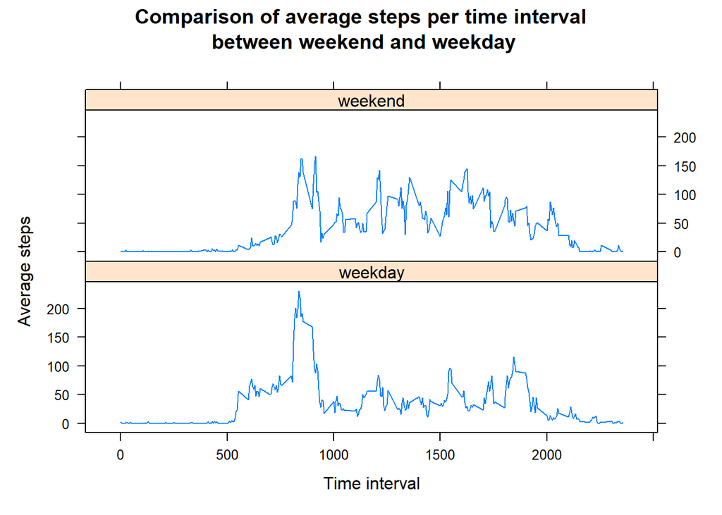

```r
library(lattice)
xyplot(steps_time_Wdays$steps~steps_time_Wdays$time_interval|steps_time_Wdays$wday,
       type="l",layout=c(1,2),xlab="Time interval",ylab = "Average steps",
       main="Comparison of average steps per time interval\n between weekend and weekday")
```